# POLISCI 9590 - Lab8: Association Tests

William Poirier

2025-11-17

## 0. What we'll be doing

1. The %in% operator
2. Association Tests

## 1. The %in% operator

```r
vec1 <- c(1,2,3,NA,5,6)
vec2 <- c(1,2,3,4,1,2)

# The == operator
vec1 == vec2
```

```
## [1]  TRUE  TRUE  TRUE    NA FALSE FALSE
```

```r
# The %in% operator
vec1 %in% vec2
```

```
## [1]  TRUE  TRUE  TRUE FALSE FALSE FALSE
```

```r
# This has important consequences
library(tidyverse)
library(rio)
cses <- import("cses5.rdata")

# Code in lab 7
tmp1 <- cses |>
  mutate(E2003 = ifelse(E2003>96,NA,E2003),
         educ_low=ifelse(E2003 %in% c(1:3,96),1,0),
         educ_mid=ifelse(E2003 %in% 4:5,1,0),
         educ_hig=ifelse(E2003 %in% 6:9,1,0))

table(cses$E2003,tmp1$educ_low,useNA="ifany")
```

```
##
##          0     1
##   1      0  3592
##   2      0 11334
##   3      0 13548
##   4  30983     0
##   5  11239     0
##   6   6760     0
##   7  21034     0
##   8  11314     0
##   9   1301     0
##   96     0   586
##   97   823     0
##   98   628     0
##   99  1572     0
```

```r
# What you should be doing in assignment 3
tmp2 <- cses |>
  mutate(educ_low=ifelse(E2003 %in% c(1:3,96),1,ifelse(E2003 >96,NA,0)),
         educ_mid=ifelse(E2003 %in% 4:5,1,      ifelse(E2003 >96,NA,0)),
         educ_hig=ifelse(E2003 %in% 6:9,1,      ifelse(E2003 >96,NA,0)))

table(cses$E2003,tmp2$educ_low,useNA="ifany")
```

```
##
##          0     1  <NA>
##   1      0  3592     0
##   2      0 11334     0
##   3      0 13548     0
##   4  30983     0     0
##   5  11239     0     0
##   6   6760     0     0
##   7  21034     0     0
##   8  11314     0     0
##   9   1301     0     0
##   96     0   586     0
##   97     0     0   823
##   98     0     0   628
##   99     0     0  1572
```

## 2. Association Tests

### 2.1 Contigency tables/cross-tabs

The frequency of each combination made by two variables.

- For frequencies: `table()`
- For percentages: `prop.table(table(),margin=2)`
  - Here `margin=2` implies that the columns will sum up to 100.
  - `margin=1` makes it so that rows sum up to 100.
  - Usually, put the DV in the rows and IV in the columns.
- There is also a `DAMisc` function: `xt`

```r
# install.packages("wooldridge")
data(happiness, package="wooldridge")
dat <- happiness %>%
  slice(sample(1:nrow(happiness),3000)) %>%
  mutate(happy=fct_rev(droplevels(happy)),
         income=droplevels(income),
         attend=droplevels(attend),
         divorce=droplevels(divorce),
         workstat=droplevels(workstat),
         wrkFTime=ifelse(workstat=="working fulltime",1,0),
         workstat_cat=case_when(workstat=="working fulltime"~"Fulltime",
                                workstat=="working parttime" ~"Parttime",
                                workstat=="retired"~"Retired",
                                workstat=="keeping house"~"Keeping house",
                                workstat %in% c("temp not working",
                                                "unempl, laid off",
                                                "retired",
                                                "school",
                                                "other") ~ "Unemployed",
                                TRUE~ NA),
         educMoreHS=ifelse(educ>=13,1,0),
         kids=ifelse(babies==0&preteen==0&teens==0,0,1))

prop.table(table(dat$happy,dat$reg16),margin = 2)
```

```
##
##                    foreign new england middle atlantic e. nor. central
##   not too happy 0.15348837  0.09790210      0.13191489      0.12110727
##   pretty happy  0.53953488  0.57342657      0.54468085      0.57958478
##   very happy    0.30697674  0.32867133      0.32340426      0.29930796
##
##                 w. nor. central south atlantic e. sou. central w. sou. central
##   not too happy      0.10222222     0.14252874      0.15736041      0.09602649
##   pretty happy       0.59111111     0.51494253      0.52284264      0.60927152
##   very happy         0.30666667     0.34252874      0.31979695      0.29470199
##
##                   mountain    pacific
##   not too happy 0.10897436 0.09318996
##   pretty happy  0.60256410 0.58422939
##   very happy    0.28846154 0.32258065
```

```r
tab <- xt(dat,"happy","reg16")
tab$tab
```

```
## [[1]]
##    happy/reg16    foreign new england middle atlantic e. nor. central
##  not too happy  15%  (33)   10%  (14)       13%  (62)       12%  (70)
##   pretty happy  54% (116)   57%  (82)       54% (256)       58% (335)
##     very happy  31%  (66)   33%  (47)       32% (152)       30% (173)
##          Total 100% (215)  100% (143)      100% (470)      100% (578)
##  w. nor. central south atlantic e. sou. central w. sou. central   mountain
##        10%  (23)      14%  (62)       16%  (31)       10%  (29)  11%  (17)
##        59% (133)      51% (224)       52% (103)       61% (184)  60%  (94)
##        31%  (69)      34% (149)       32%  (63)       29%  (89)  29%  (45)
##       100% (225)     100% (435)      100% (197)      100% (302) 100% (156)
##     pacific        Total
##    9%  (26)  12%   (367)
##   58% (163)  56% (1,690)
##   32%  (90)  31%   (943)
##  100% (279) 100% (3,000)
```

```r
tab$stats
```

```
## [[1]]
##               statistic p-value
## Chi-squared 18.66565814   0.412
## Cramers V    0.05577583   0.412
## Lambda       0.00000000   1.000
```

You might ask whether those two variables are related in the population or not:

- $H_0:$ Variables X and Y are independent in the population.
- $H_A:$ Variables X and Y are not independent in the population.

You'll learn about the $\chi^2$ test on Wednesday.

### 2.2 Which test?

| Test | Data type | Why do we use it? | Interpretation |
| --- | --- | --- | --- |
| $\chi^2$ | Nominal | Are the frequencies of the contingency table of the two variables randomly distributed? | $H_0$: Frequencies are randomly distributed. |
| $\phi$ | Nominal (2x2 table) | How strong is the relationship (-1 to 1)? | 0=no >0.1=moderate >0.3=strong |
| Cramer's V | Nominal (>2x2 table) | How strong is the relationship (-1 to 1)? | 0=no >0.1=moderate >0.3=strong |
| $\lambda$ | Nominal | What is the exact improvement in error in predicting DV by knowing IV? | Percent improvement |
| $\gamma$ | Ordinal | How strong is the relationship (-1 to 1)? | 0=no >0.1=moderate >0.3=strong |
| Somer's d | Ordinal | How strong is the relationship (-1 to 1)? (A $\gamma$ that accounts for ties on IV) | 0=no >0.1=moderate >0.3=strong |
| Kendall's $\tau_b$ | Ordinal | How strong is the relationship (-1 to 1)? (A $\gamma$ that accounts for ties on IV and DV) | 0=no >0.1=moderate >0.3=strong |
| Spearman's $\rho_s$ | Ordinal | How strong is the relationship (-1 to 1)? (Talk of a correlation. Testing for monotonic relationship) | 0=no >0.1=moderate >0.3=strong |
| Pearson r | Continuous | How strong is the relationship (-1 to 1)? (Talk of a correlation. Testing for linear relationship) | 0=no >0.1=moderate >0.3=strong |

- \(°□°)/ ''Greek ABCs!'' \(°□°)/

| Letter | Name | Letter | Name |
| --- | --- | --- | --- |
| $A \alpha$ | Alpha | $N\nu$ | Nu |
| $B \beta$ | Beta | $\Xi\xi$ | Xi |
| $\Gamma\gamma$ | Gamma | $O\omicron$ | Omicron |
| $\Delta\delta$ | Delta | $\Pi\pi$ | Pi |
| $E\epsilon/\varepsilon$ | Epsilon | $P\rho$ | Rho |
| $Z\zeta$ | Zeta | $\Sigma\sigma$ | Sigma |
| $H\eta$ | Eta | $T\tau$ | Tau |
| $\Theta\theta$ | Theta | $\Upsilon\upsilon$ | Upsilon |
| $I\iota$ | Iota | $\Phi\phi$ | Phi |
| $K\kappa$ | Kappa | $X\chi$ | Chi |
| $\Lambda\lambda$ | Lambda | $\Psi\psi$ | Psi |
| $M\mu$ | Mu | $\Omega\omega$ | Omega |

- One function to rule them all: `uwo4419::makeStats`

### 2.3 Nominal Association Test Example

Using the variables `income`,`attend`,`wrkFTime`,`educMoreHS`,`kids`, calculate measures of association for the relationship between each of these and `happy`. Make a plot that shows the effects of each variable.

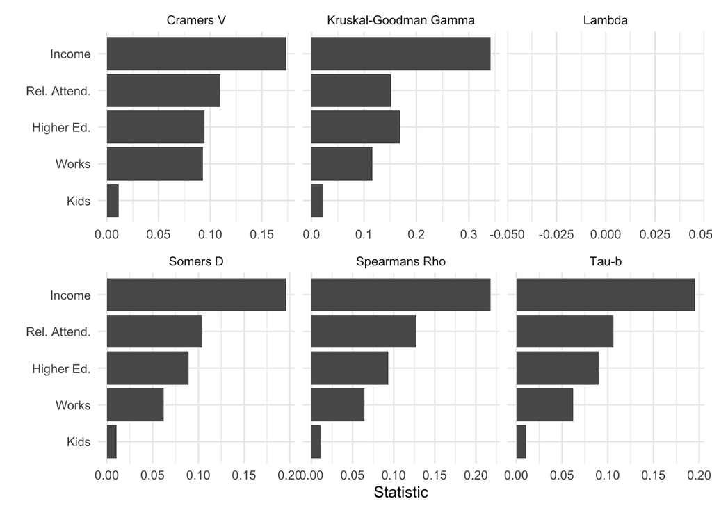

```r
# Stats
library(uwo4419)
stat_income     <- makeStats(dat$happy,dat$income,    lambda=T,cramersV=T,chisq=T,gamma=T,d=T,taub=T,rho=T)
stat_attend     <- makeStats(dat$happy,dat$attend,    lambda=T,cramersV=T,chisq=T,gamma=T,d=T,taub=T,rho=T)
stat_wrkFTime   <- makeStats(dat$happy,dat$wrkFTime,  lambda=T,cramersV=T,chisq=T,gamma=T,d=T,taub=T,rho=T)
stat_educMoreHS <- makeStats(dat$happy,dat$educMoreHS,lambda=T,cramersV=T,chisq=T,gamma=T,d=T,taub=T,rho=T)
stat_kids       <- makeStats(dat$happy,dat$kids,      lambda=T,cramersV=T,chisq=T,gamma=T,d=T,taub=T,rho=T)

# Data for Graph
stats <- bind_rows(stat_income %>% as_tibble(rownames="stat") %>% mutate(var="Income"),
                   stat_attend %>% as_tibble(rownames="stat") %>% mutate(var="Rel. Attend."),
                   stat_wrkFTime %>% as_tibble(rownames="stat") %>% mutate(var="Works"),
                   stat_educMoreHS %>% as_tibble(rownames="stat") %>% mutate(var="Higher Ed."),
                   stat_kids %>% as_tibble(rownames="stat") %>% mutate(var="Kids"))

# Graph
ggplot(stats %>% filter(stat!="Chi-squared"),aes(x=reorder(as.factor(var), statistic, mean), y=statistic)) +
  geom_bar(stat="identity") +
  facet_wrap(~stat,scales = "free_x") +
  theme_minimal() +
  labs(x="", y="Statistic")+
  coord_flip()
```

### 2.4 Variance, Covariance and Correlation

- Sample variance of Y:
  $$\sigma_Y=\frac{\sum_{i=1}^n(Y_i-\bar
  Y)^2}{n-1}$$
- Sample covariance between X and Y:
  $$cov(X,Y)=\frac{\sum_{i=1}^n (X_i-\bar X)(Y_i-\bar
  Y)}{n-1}$$
- Pearson correlation between X and Y:
  $$r_{XY}=\frac{\sum_{i=1}^n(X_i-\bar X)(Y_i-\bar
  Y)}{\sqrt{\sum_{i=1}^n(X_i-\bar X)^2\sum_{i=1}^n(Y_i-\bar
  Y)^2}}$$
- R functions:
  - Covariance: `cov`
  - Correlation: `cor`
    - There is also `DAMisc::pwCorrMat()` to produce a correlation matrix, more on this in a bit.

```r
# A random variable X
X <- rnorm(1000,0,1)

# Another random variable Y
Ypos <- rnorm(1000,0,1)+X
Ynull <- rnorm(1000,0,1)+rnorm(1000,0,1)
Yneg <- rnorm(1000,0,1)-X

FakeData <- data.frame(X=X,Ypos=Ypos,Ynull=Ynull,Yneg=Yneg)

# Variance covariance matrix
cov(FakeData)
```

```
##                 X          Ypos         Ynull        Yneg
## X      1.00576319  1.0098977468  0.0259181614 -1.02344345
## Ypos   1.00989775  1.9904549383  0.0004238368 -1.01800984
## Ynull  0.02591816  0.0004238368  2.0387405539 -0.02177242
## Yneg  -1.02344345 -1.0180098427 -0.0217724240  2.02154498
```

```r
# Correlations
cor(FakeData[,1],FakeData[,2:4])
```

```
##           Ypos      Ynull       Yneg
## [1,] 0.7137619 0.01809987 -0.7177518
```

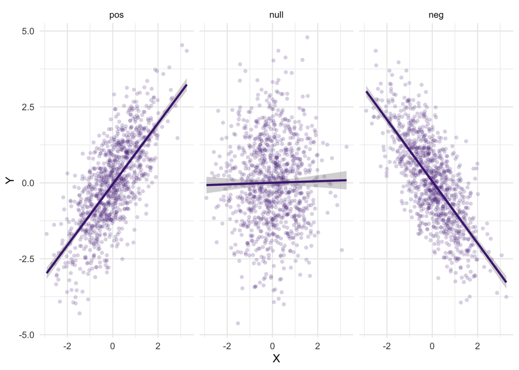

```r
# Vizualisation
FakeData %>%
  pivot_longer(starts_with("Y"),values_to = "Y",names_to = "var",names_pattern = "Y(.*)") %>%
  mutate(var=factor(var,levels=c("pos","null","neg"))) %>%
  ggplot(aes(x=X,y=Y))+
  geom_point(alpha=0.2,color="#4F2683",shape=16)+
  geom_smooth(method="lm",color="#4F2683")+
  facet_wrap(~var)+
  theme_minimal()
```

### 2.5 Functions to copy and paste

```r
custom_smooth <- function(data, mapping,
                          ..., span=.35, pt.alpha=.25, jitter=TRUE) {
  if(jitter){
    pos <- position_jitter(width=2, height=2)
  }else{
    pos <- position_identity()
  }
  ggplot(data, mapping, ...) +
    geom_point(shape=1, col="gray",
               position=pos, alpha=pt.alpha) +
    geom_smooth(method="loess", span=span,
                family="symmetric",
                se=FALSE, col="red") +
    geom_smooth(method="lm", col="black", se=FALSE)
}

check_lin <- function(formula, data, ...){
  requireNamespace("fANCOVA")
  D <- get_all_vars(formula, data)
  D <- na.omit(D)
  if(nrow(D) == 0)stop("No non-missing data.\n")
  forms <- sapply(names(D)[-1], \(x)reformulate(x, response=names(D)[1]))
  y <- c(D[,1])
  X <- as.matrix(D[,-1])
  spans <- sapply(1:ncol(X), \(i)fANCOVA::loess.as(X[,i], y, criterion = "gcv")$pars$span)
  los <- lapply(seq_along(forms), \(i)do.call(loess, list(formula=forms[[i]], data=D, span=spans[i])))
  lms <- lapply(seq_along(forms), \(i)do.call(lm, list(formula=forms[[i]], data=D)))
  n <- nrow(D)
  rss0 <- sapply(lms, \(x)sum(x$residuals^2))
  rss1 <- sapply(los, \(x)sum(x$residuals^2))
  df.linmod <- sapply(lms, \(x)x$rank)
  df.lomod <- sapply(los, \(x)x$trace.hat)
  df.res <- n-df.lomod
  F0 <- ((rss0-rss1)/(df.lomod-df.linmod))/(rss1 / df.res)
  pval <- pf(F0, (df.lomod-df.linmod), df.res, lower.tail=FALSE)
  nl_r2 <- sapply(los, \(m)cor(m$y, m$fitted)^2)
  lin_r2 <- sapply(lms, \(m)cor(m$fitted.values, model.response(model.frame(m)))^2)
  out <- data.frame(vbl = names(D)[-1], lin_r2 = lin_r2, nonlin_r2 = nl_r2)
  out$diff <- out$nonlin_r2 - out$lin_r2
  out$p <- pval
  class(out) <- c("checklin", class(out))
  return(out)
}
```

### 2.6 Correlation Examples

```r
#install.packages("GGally")
library(GGally)

# Data
data(countymurders, package="wooldridge")
sub <- countymurders %>%
  filter(year==1996) %>%
  select(murdrate,arrestrate,percblack,percmale,rpcpersinc)

# Correlations
DAMisc::pwCorrMat(murdrate~arrestrate+percblack+percmale+rpcpersinc,data=sub)
```

```
## Pairwise Correlations
##            murdrate arrestrate percblack percmale rpcpersinc
## murdrate
## arrestrate 0.567*
## percblack  0.380*   0.381*
## percmale   -0.081*  -0.095*    -0.262*
## rpcpersinc -0.073*  -0.105*    -0.065*   -0.121*
```

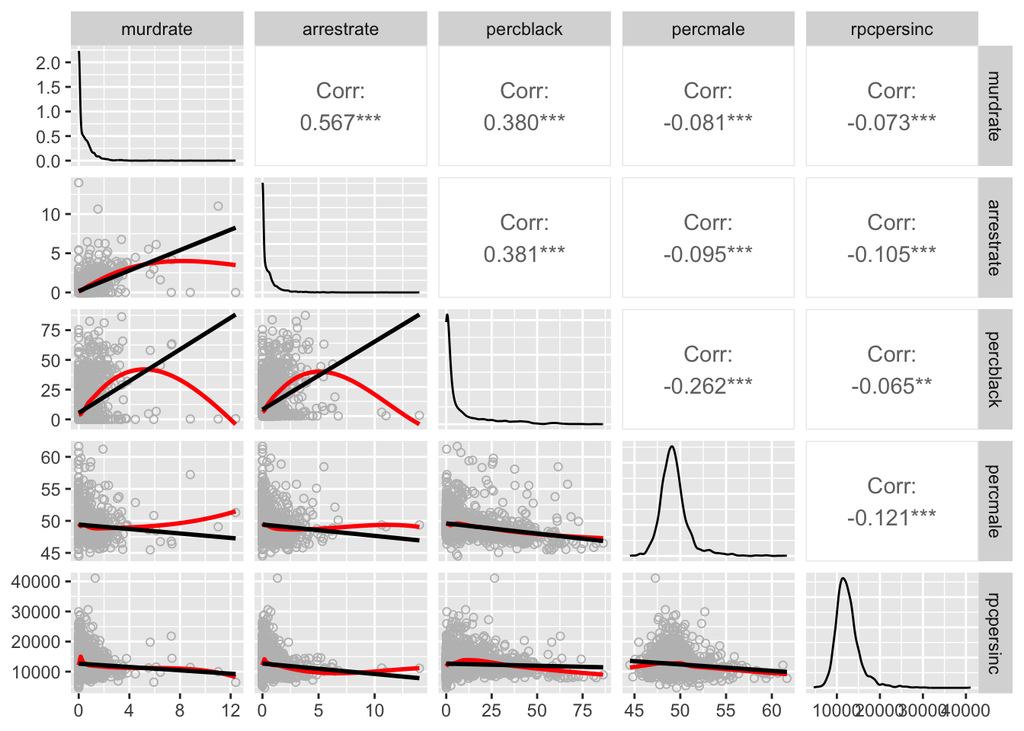

```r
# Visualize
ggpairs(sub,
        lower = list(continuous = wrap(custom_smooth,
                                       span=.5,
                                       pt.alpha=1,
                                       jitter=FALSE))) +
  theme(legend.position = "bottom")
```

```r
# Test for non-linearity
check_lin(murdrate~arrestrate+percblack+percmale+rpcpersinc,data=sub)
```

```
##          vbl      lin_r2  nonlin_r2         diff            p
## 1 arrestrate 0.321954125 0.35841350 0.0364593719 1.598702e-25
## 2  percblack 0.144494166 0.14486312 0.0003689559 8.261143e-01
## 3   percmale 0.006610729 0.06359355 0.0569828165 1.106390e-24
## 4 rpcpersinc 0.005380532 0.01991495 0.0145344160 3.271076e-06
```

#### 2.6.1 X1 and X2

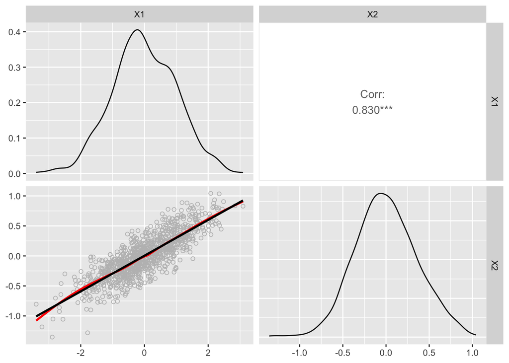

```
##   vbl    lin_r2 nonlin_r2        diff         p
## 1  X1 0.6884561 0.6896512 0.001195098 0.2169462
```

- Linearity?

  Linear Not
- Significance?

  Significant Not
- Strong relationship?

  Strong Not

#### 2.6.2 X1 and X3

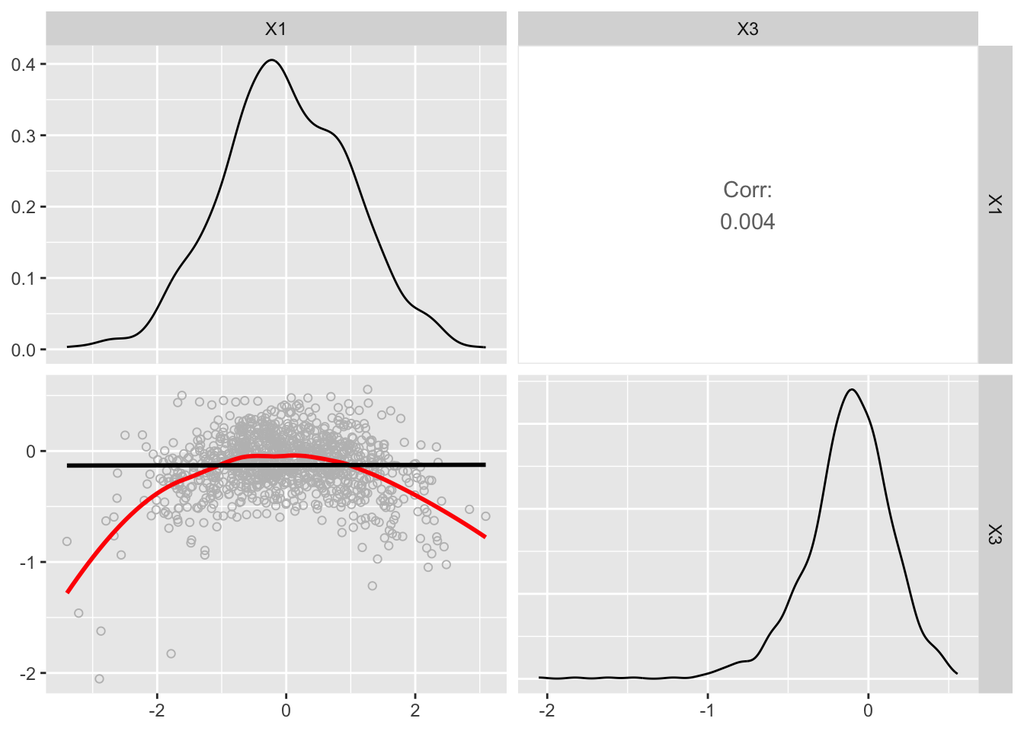

```
##   vbl     lin_r2 nonlin_r2      diff            p
## 1  X1 1.4076e-05 0.2230931 0.2230791 1.619498e-49
```

- Linearity?

  Linear Not
- Significance?

  Significant Not
- Strong relationship?

  Strong Not

#### 2.6.3 X1 and X4

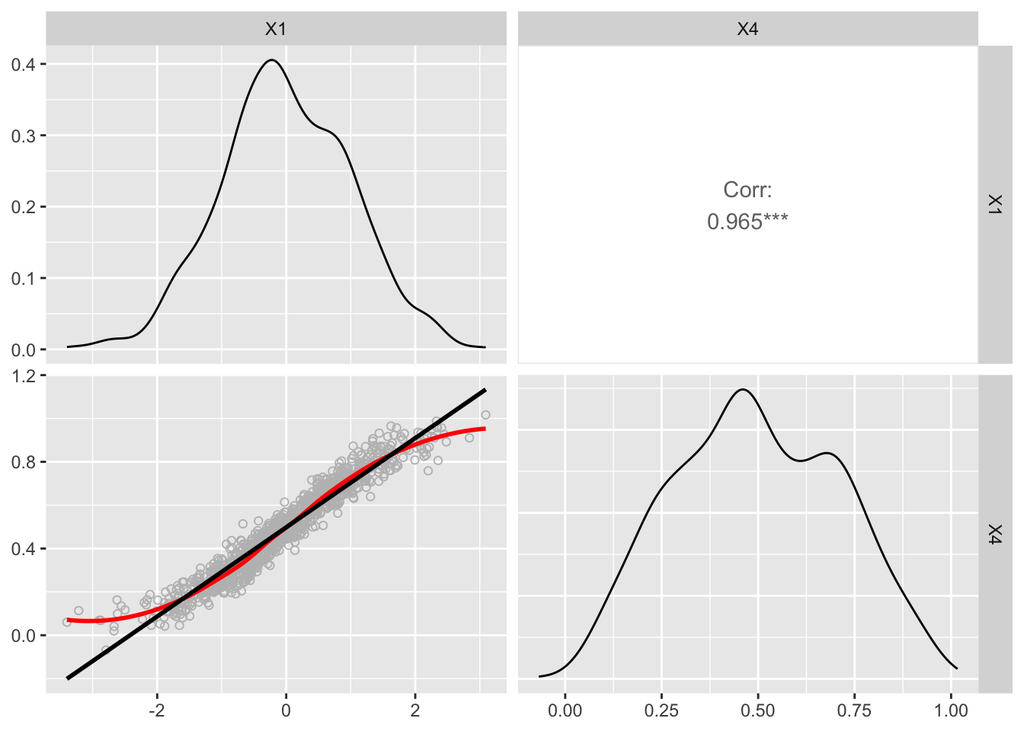

```
##   vbl    lin_r2 nonlin_r2       diff            p
## 1  X1 0.9314118 0.9477851 0.01637333 2.671061e-48
```

- Linearity?

  Linear Not
- Significance?

  Significant Not
- Strong relationship?

  Strong Not

#### 2.6.4 X1 and X5

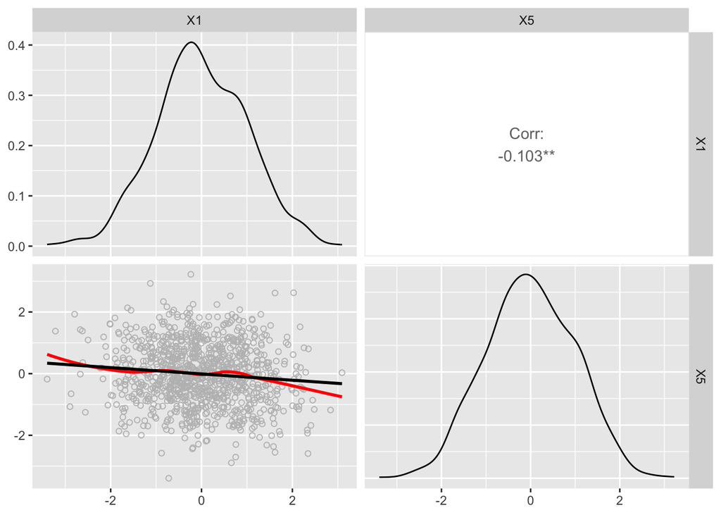

```
##   vbl     lin_r2  nonlin_r2        diff         p
## 1  X1 0.01063344 0.01509156 0.004458115 0.1568782
```

- Linearity?

  Linear Not
- Significance?

  Significant Not
- Strong relationship?

  Strong Not

#### 2.6.5 X1 and X6

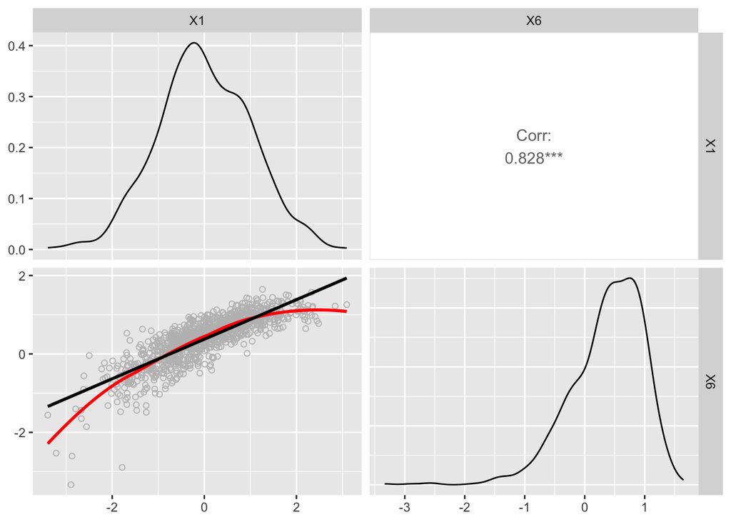

```
##   vbl    lin_r2 nonlin_r2       diff            p
## 1  X1 0.6864107 0.7244987 0.03808802 1.016584e-24
```

- Linearity?

  Linear Not
- Significance?

  Significant Not
- Strong relationship?

  Strong Not